# Reproducible Research: Peer Assessment 1

This is a report genereated by the “knitr” package for Reproducible Research: Peer Assessment Project 1.

Before any analysis can be done, we need to load some R packages.

```r
# Load some R packages
library(plyr)
library(ggplot2)
```

## Loading and preprocessing the data

In this step, the data is loaded and preprocessed. The data file should be downloaded and extracted into the R work directory already.

```r
# Read the data
activityData <- read.csv("data/activity.csv", stringsAsFactors=FALSE)
# Convert "date" to Date format
activityData$date <- as.Date(activityData$date)
```

## What is mean total number of steps taken per day?

We first create a histogram for the total number of steps taken each day:

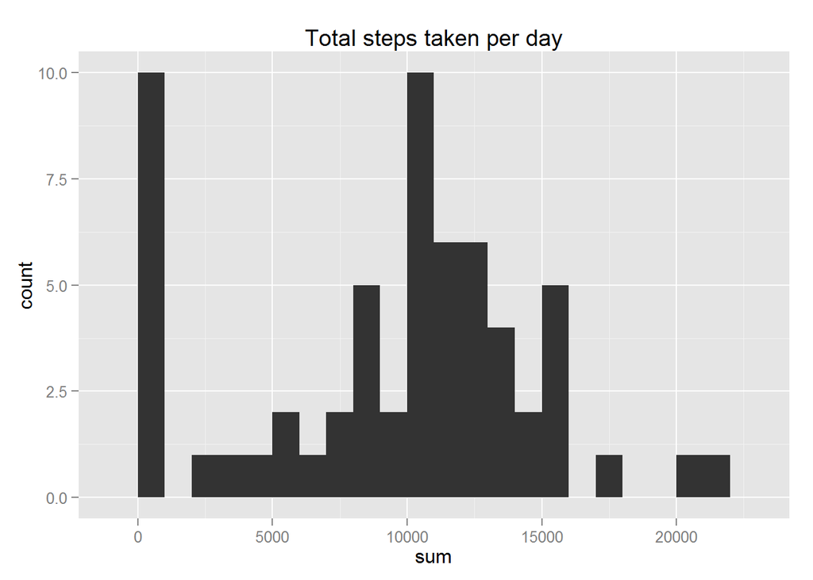

```r
stepsByDay <- ddply(activityData, "date", summarize, sum = sum(steps, na.rm=TRUE))
ggplot(stepsByDay, aes(sum)) + geom_histogram(binwidth=1000) + ggtitle("Total steps taken per day")
```

The mean total number of steps per day is:

```r
mean(stepsByDay$sum)
```

```
## [1] 9354.23
```

The median total number of steps per day is:

```r
median(stepsByDay$sum)
```

```
## [1] 10395
```

```r
remove(stepsByDay)
```

## What is the average daily activity pattern?

We create a time series plot with x being the 5-minute interval and y being the average number of steps taken, averaged across all days.

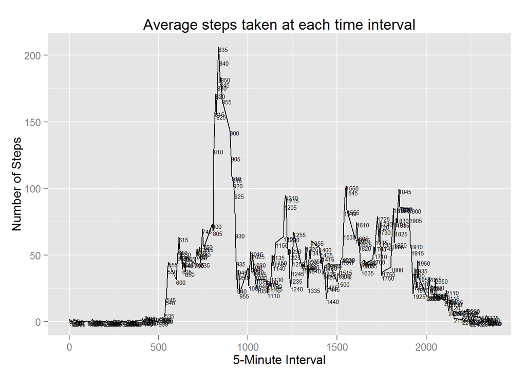

```r
stepsByInt <- ddply(activityData, "interval", summarize, meanSteps = mean(steps, na.rm=TRUE))
ggplot(stepsByInt, aes(interval,meanSteps)) +
  geom_line() +
  geom_text(aes(label=interval),size=2,hjust=0, vjust=1) +
  ggtitle("Average steps taken at each time interval") +
  labs(x = "5-Minute Interval", y="Number of Steps")
```

From this plot, we can conclude that the interval 835 contains the maximum number of steps.

## Imputing missing values

First, we calculate the total number of missing values in the dataset:

```r
sum(is.na(activityData$step))
```

```
## [1] 2304
```

Then, we create a new dataset that is equal to the original dataset but with the missing data filled in with the mean of the same time interval.

```r
newData <- ddply(activityData,"interval", transform, steps = replace(steps, is.na(steps), mean(steps, na.rm = TRUE)))
newData <- newData[order(newData$date),]
```

At last, we make a histogram of the total number of steps taken each day and Calculate and report the mean and median total number of steps taken per day.

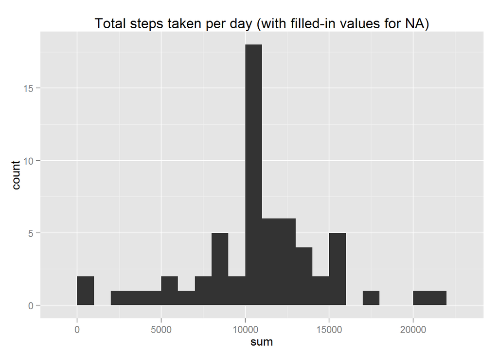

```r
stepsByDay <- ddply(newData, "date", summarize, sum = sum(steps, na.rm=TRUE))
ggplot(stepsByDay, aes(sum)) + geom_histogram(binwidth=1000) + ggtitle("Total steps taken per day (with filled-in values for NA)")
```

The mean total number of steps per day is:

```r
mean(stepsByDay$sum)
```

```
## [1] 10766.19
```

The median total number of steps per day is:

```r
median(stepsByDay$sum)
```

```
## [1] 10766.19
```

```r
#remove(stepsByDay)
```

## Are there differences in activity patterns between weekdays and weekends?

First, we create a new factor variable “dayOfWeek”: the value will be “weekday” for weekdays and “weekend” for Saturdays and Sundays.

```r
newData$dayOfWeek <- sapply(newData[,"date"],
                            function(x) { if (weekdays(x) %in% c("Saturday","Sunday")) {"weekend"} else {"weekday"} })
```

Then we can make one time series plot for each value:

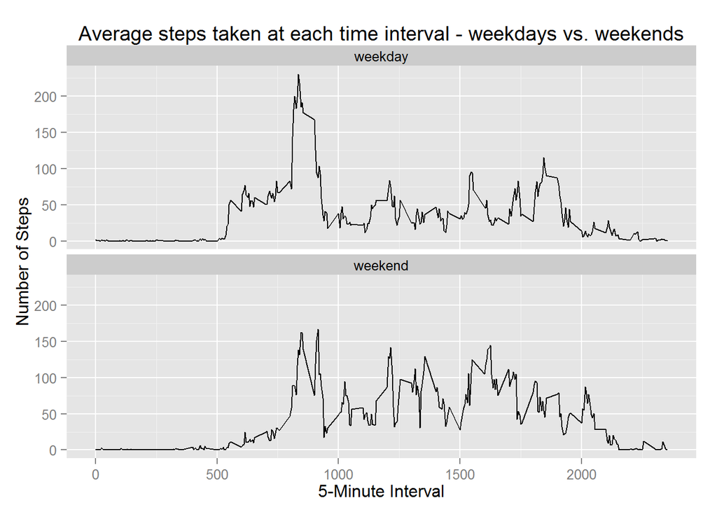

```r
ggplot(ddply(newData, c("interval","dayOfWeek"), summarize, meanSteps = mean(steps, na.rm=TRUE)), aes(interval,meanSteps)) +
  geom_line() +
  facet_wrap(~dayOfWeek, ncol=1) +
  ggtitle("Average steps taken at each time interval - weekdays vs. weekends") +
  labs(x = "5-Minute Interval", y="Number of Steps")
```

From the plot above, it can be clearly seen that the patterns are different for weekdays and weekends. For weekdays, there is a peak in the early morning, whereas the steps are more evenly distributed through the deay for weekends.